# Tarea 7 Datos faltantes

Mario Becerra 124362

24/03/2015

```r
library(dplyr)
library(tidyr)
library(ggplot2)
library(mi)
```

Se usarán los datos de enfermedades del corazón en Sudáfrica, obtenidos del paquete *ElemStatLearn* de R. A estos datos les llamaremos los *datos íntegros*.

Descripción de las variables:

- sbp: systolic blood pressure
- tobacco: cumulative tobacco (kg)
- ldl: low density lipoprotein cholesterol
- adiposity: a numeric vector
- famhist: family history of heart disease, a factor with levels Absent Present
- typea: type-A behavior
- obesity: a numeric vector
- alcohol: current alcohol consumption
- age: age at onset
- chd: response, coronary heart disease

```r
library(ElemStatLearn)
datos <- SAheart
head(datos)
```

```
##   sbp tobacco  ldl adiposity famhist typea obesity alcohol age chd
## 1 160   12.00 5.73     23.11 Present    49   25.30   97.20  52   1
## 2 144    0.01 4.41     28.61  Absent    55   28.87    2.06  63   1
## 3 118    0.08 3.48     32.28 Present    52   29.14    3.81  46   0
## 4 170    7.50 6.41     38.03 Present    51   31.99   24.26  58   1
## 5 134   13.60 3.50     27.78 Present    60   25.99   57.34  49   1
## 6 132    6.20 6.47     36.21 Present    62   30.77   14.14  45   0
```

Vamos a un programa que resulte en que aproximadamente la mitad de los datos de la variable *ldl* sean faltantes dependiendo de *adiposity* de tal manera que los faltantes sean aleatorios pero no completamente aleatorios, esto es, la probabilidad de que falte *ldl* depende de *adiposity* (MAR pero no MCAR). Llamaremos a estos datos los *datos disponibles*.

El mecanismo de faltantes es que si el valor de *adiposity* es mayor a su media, entonces va a faltar el dato de esta fila en *ldl*.

```r
datos$ldl_miss <- datos$ldl
datos$ldl_miss[datos$adiposity > mean(datos$adiposity)] <- NA
sum(is.na(datos$ldl_miss))/nrow(datos)
```

```
## [1] 0.5411255
```

De esta forma, el 54.11% de los datos en *ldl_miss* es faltante y depende de la media de *adiposity*.

Realizaremos ahora una regresión de datos completos con los datos disponibles donde *adiposity* es predictor y *ldl* es la variable respuesta.

```r
mod1 <- lm(ldl_miss~adiposity, data=datos)
summary(mod1)
```

```
##
## Call:
## lm(formula = ldl_miss ~ adiposity, data = datos)
##
## Residuals:
##     Min      1Q  Median      3Q     Max
## -3.2274 -1.0289 -0.1465  0.5068 11.0542
##
## Coefficients:
##             Estimate Std. Error t value Pr(>|t|)
## (Intercept)   1.8076     0.4331   4.174 4.39e-05 ***
## adiposity     0.1122     0.0228   4.920 1.74e-06 ***
## ---
## Signif. codes:  0 '***' 0.001 '**' 0.01 '*' 0.05 '.' 0.1 ' ' 1
##
## Residual standard error: 1.556 on 210 degrees of freedom
##   (250 observations deleted due to missingness)
## Multiple R-squared:  0.1034, Adjusted R-squared:  0.09909
## F-statistic: 24.21 on 1 and 210 DF,  p-value: 1.744e-06
```

Compararemos estos resultados con una regresión con los *datos íntegros*.

```r
mod2 <- lm(ldl~adiposity, data=datos)
summary(mod2)
```

```
##
## Call:
## lm(formula = ldl ~ adiposity, data = datos)
##
## Residuals:
##     Min      1Q  Median      3Q     Max
## -3.6448 -1.1833 -0.1558  0.7117 10.9890
##
## Coefficients:
##             Estimate Std. Error t value Pr(>|t|)
## (Intercept)  1.76201    0.29601   5.952 5.24e-09 ***
## adiposity    0.11723    0.01114  10.522  < 2e-16 ***
## ---
## Signif. codes:  0 '***' 0.001 '**' 0.01 '*' 0.05 '.' 0.1 ' ' 1
##
## Residual standard error: 1.861 on 460 degrees of freedom
## Multiple R-squared:  0.194,  Adjusted R-squared:  0.1922
## F-statistic: 110.7 on 1 and 460 DF,  p-value: < 2.2e-16
```

Vemos que los resultados son consistentes uno con otro. Esto se puede ver de manera gráfica que ambas líneas son prácticamente iguales.

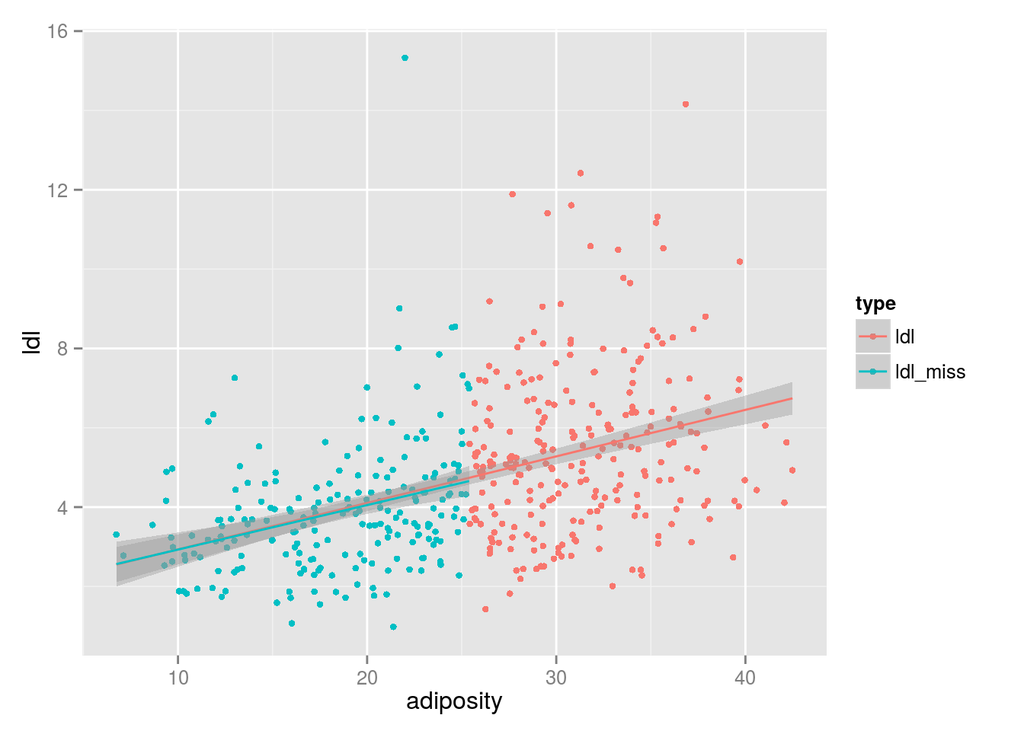

```r
datos_graf <- datos[,c(3,4,11)] %>% gather(type, value, ldl,ldl_miss)

ggplot(datos_graf, aes(x = adiposity, y = value)) +
  geom_point(aes(x = adiposity, y = value, colour = type), size = 1.5) +
  geom_smooth(aes(x = adiposity, y = value, group = type, color = type), method = "lm", se = TRUE) +
  ylab('ldl')
```

Probemos ahora tomando *ldl* como predictor y *adiposity* como variable respuesta. Primero con los *datos disponibles*.

```r
mod3 <- lm(adiposity~ldl_miss, data=datos)
summary(mod3)
```

```
##
## Call:
## lm(formula = adiposity ~ ldl_miss, data = datos)
##
## Residuals:
##      Min       1Q   Median       3Q      Max
## -11.1484  -3.7684   0.4487   3.8002   7.9206
##
## Coefficients:
##             Estimate Std. Error t value Pr(>|t|)
## (Intercept)  14.8388     0.7872   18.85  < 2e-16 ***
## ldl_miss      0.9213     0.1873    4.92 1.74e-06 ***
## ---
## Signif. codes:  0 '***' 0.001 '**' 0.01 '*' 0.05 '.' 0.1 ' ' 1
##
## Residual standard error: 4.459 on 210 degrees of freedom
##   (250 observations deleted due to missingness)
## Multiple R-squared:  0.1034, Adjusted R-squared:  0.09909
## F-statistic: 24.21 on 1 and 210 DF,  p-value: 1.744e-06
```

Ahora con los *datos íntegros*.

```r
mod4 <- lm(adiposity~ldl, data=datos)
summary(mod4)
```

```
##
## Call:
## lm(formula = adiposity ~ ldl, data = datos)
##
## Residuals:
##      Min       1Q   Median       3Q      Max
## -20.9301  -4.8397  -0.1138   5.1020  17.6963
##
## Coefficients:
##             Estimate Std. Error t value Pr(>|t|)
## (Intercept)  17.5626     0.8134   21.59   <2e-16 ***
## ldl           1.6548     0.1573   10.52   <2e-16 ***
## ---
## Signif. codes:  0 '***' 0.001 '**' 0.01 '*' 0.05 '.' 0.1 ' ' 1
##
## Residual standard error: 6.993 on 460 degrees of freedom
## Multiple R-squared:  0.194,  Adjusted R-squared:  0.1922
## F-statistic: 110.7 on 1 and 460 DF,  p-value: < 2.2e-16
```

Vemos que ahora las *betas* de la regresión no son consistentes y difieren en mayor manera que en los dos modelos anteriores. Esto se puede ver gráficamente a continuación, donde las rectas difieren mucho más que en la gráfica anterior.

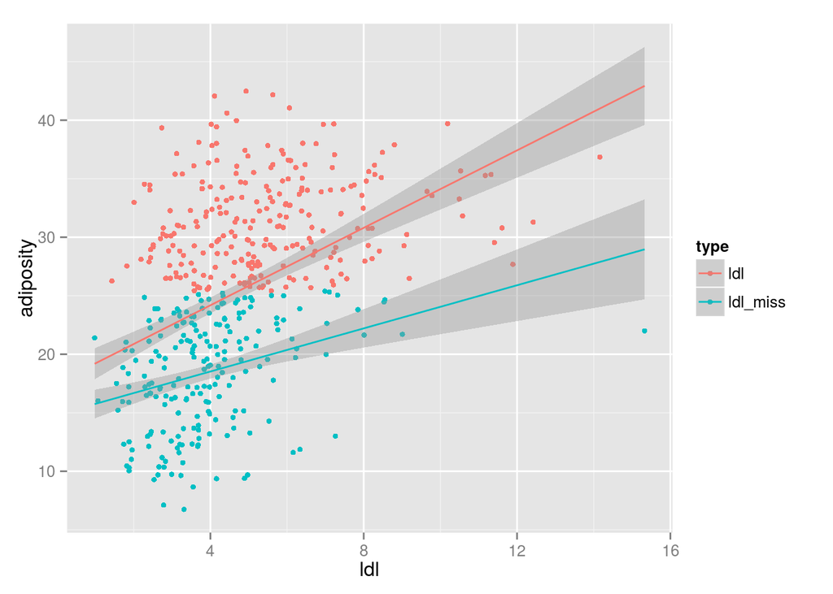

```r
ggplot(datos_graf, aes(x = value, y = adiposity)) +
  geom_point(aes(x = value, y = adiposity, colour = type), size = 1.5) +
  geom_smooth(aes(x = value, y = adiposity, group = type, color = type), method = "lm", se = TRUE) +
  xlab('ldl')
```

Ahora haremos una imputación estocástica con regresión.

```r
datos$ldl_imp_st <- datos$ldl_miss
pred_1 <- predict(mod1, newdata = subset(datos, is.na(ldl_miss)))
datos$ldl_imp_st[is.na(datos$ldl_miss)] <- pred_1 + rnorm(sum(is.na(datos$ldl_miss)), 0, sd = summary(mod1)$sigma)
```

A continuación, se puede ver que hubo mejoría en las estimaciones de la recta con *adiposity* como variable respuesta mediante imputación estocástica con regresión.

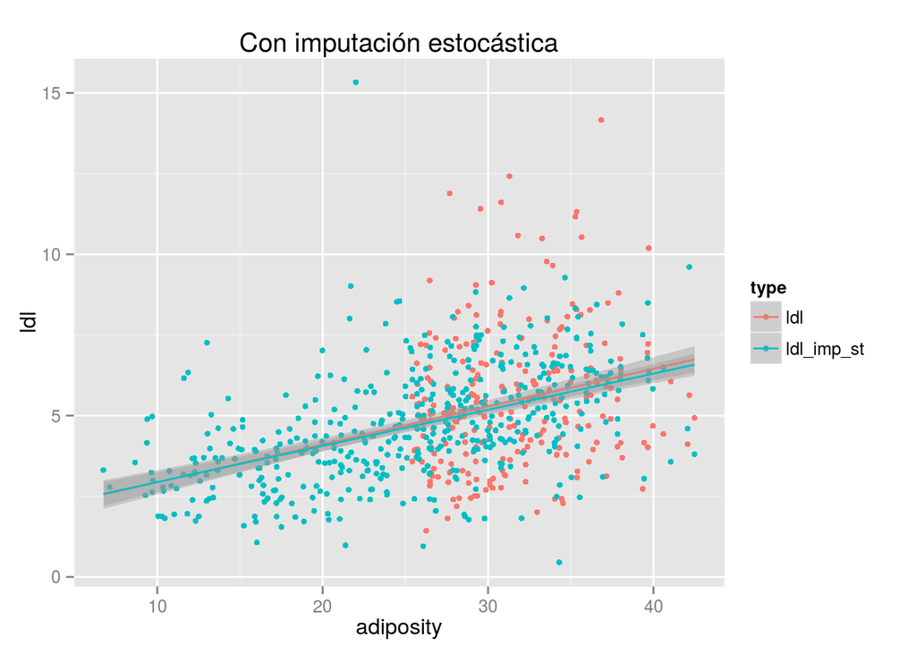

```r
datos_graf2 <- datos[,c(3,4,12)] %>% gather(type, value, ldl,ldl_imp_st)

ggplot(datos_graf2, aes(x = adiposity, y = value)) +
  geom_point(aes(x = adiposity, y = value, colour = type), size = 1.5) +
  geom_smooth(aes(x = adiposity, y = value, group = type, color = type), method = "lm", se = TRUE) +
  labs(title = "Con imputación estocástica") + ylab('ldl')
```

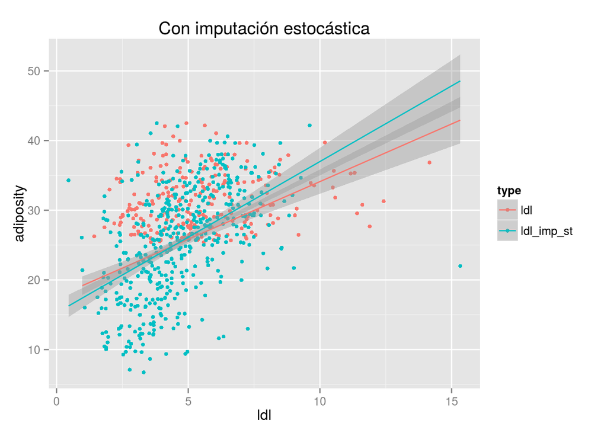

```r
ggplot(datos_graf2, aes(x = value, y = adiposity)) +
  geom_point(aes(x = value, y = adiposity, colour = type), size = 1.5) +
  geom_smooth(aes(x = value, y = adiposity, group = type, color = type), method = "lm", se = TRUE) +
  labs(title = "Con imputación estocástica") + xlab('ldl')
```

```r
info <- mi.info(datos)
info
info <- update(info, "include", list("ldl_imp_st" = FALSE, "ldl"=FALSE, "ldl_miss"=TRUE))
info
datos_2 <- mi.preprocess(datos)
attr(datos_2, "mi.info")
IMP <- mi(datos_2, n.iter = 100)
save(IMP, file='IMP.Rdata')
```

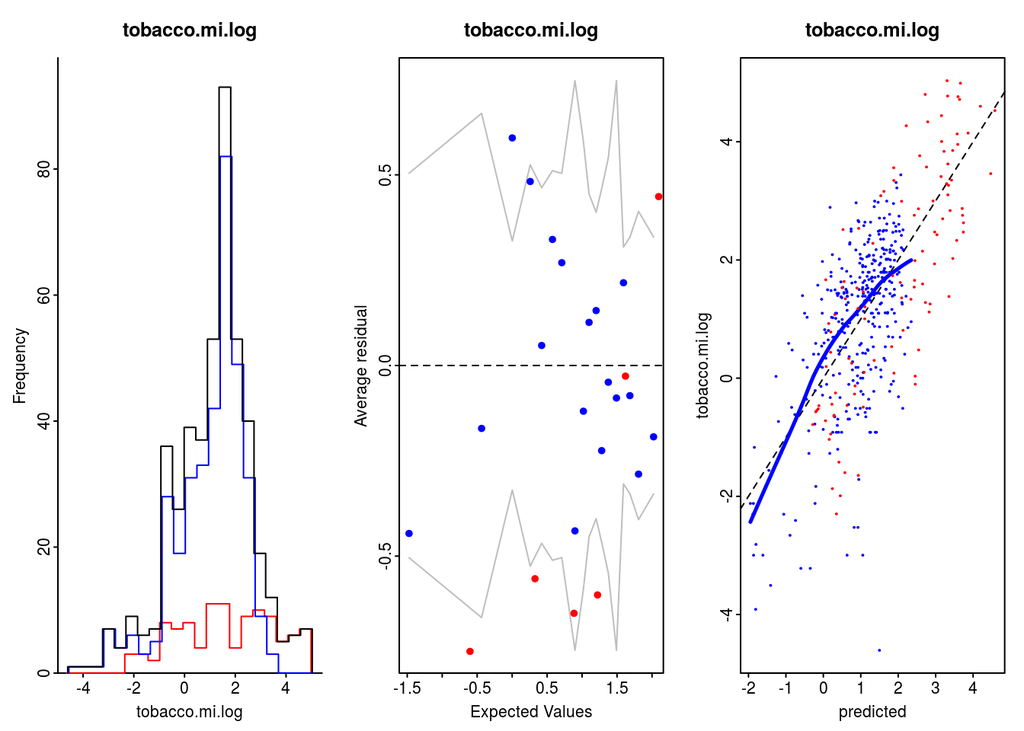

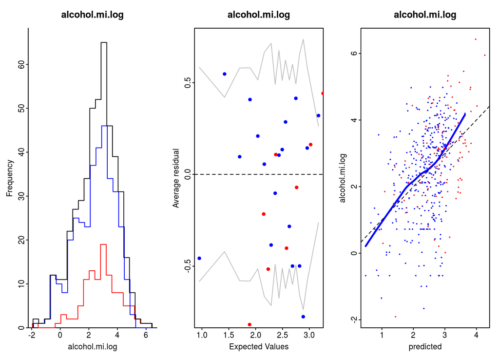

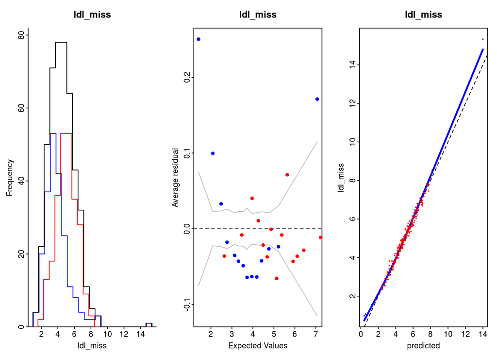

```r
load('IMP.Rdata')
plot(IMP)
```

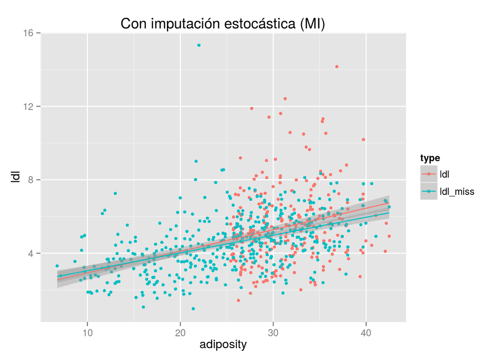

```r
IMP.dat <- mi.data.frame(IMP, m = 1)

temp <- IMP.dat[,c(4,11)]
temp$ldl <- datos$ldl
datos_graf3 <- temp %>% gather(type, value, ldl,ldl_miss)

ggplot(datos_graf3, aes(x = adiposity, y = value)) +
  geom_point(aes(x = adiposity, y = value, colour = type), size = 1.5) +
  geom_smooth(aes(x = adiposity, y = value, group = type, color = type), method = "lm", se = TRUE) +
  labs(title = "Con imputación estocástica (MI)") + ylab('ldl')
```

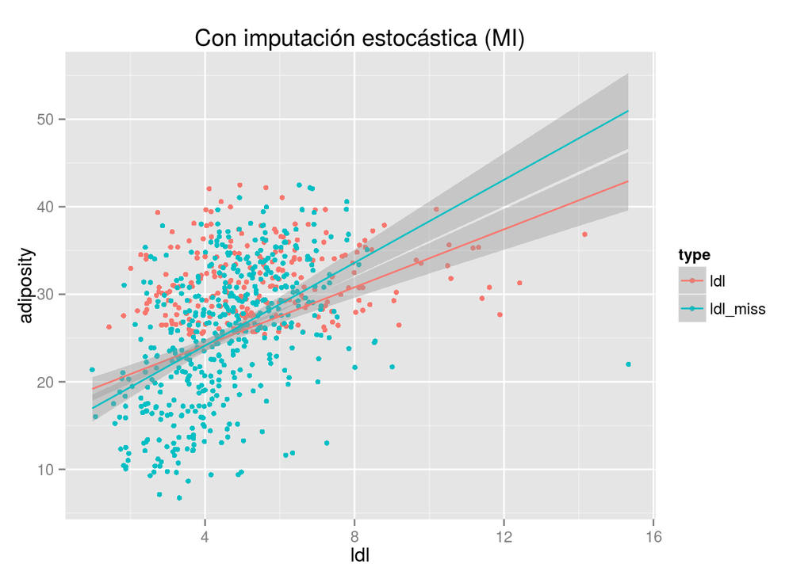

```r
ggplot(datos_graf3, aes(x = value, y = adiposity)) +
  geom_point(aes(x = value, y = adiposity, colour = type), size = 1.5) +
  geom_smooth(aes(x = value, y = adiposity, group = type, color = type), method = "lm", se = TRUE) +
  labs(title = "Con imputación estocástica (MI)") + xlab('ldl')
```